# Spatial Analysis

2019-12-02

## Overview

1. Motivation–reproducible workflows
2. Brief intro to generic spatial data (crs, projections, raster vs vector data)
3. Brief intro to spatial capabilities in R
4. Intro to the sf package
5. Reading and writing spatial data with sf (shapefiles, lat/lon, other data)
6. Geometric operations with sf
7. Making maps with sf and ggplot2

## Motivation

[figure not shown]

## Biref overview of spatial analysis

## Why spatial data?

- Interesting spatial questions
- Earth is round-ish/spherioid
- Maps and screens are flat, so we only see projected data
- Projected distances, areas, shapes, and directions are distorted

## Reference systems

- [Geodesic/geographic coordinates](https://edzer.github.io/rstudio_conf/#6) need
  - Order (lat/long vs long/lat)
  - Units (rad, arc_degree)
  - Datum (aka reference ellipsoid)
- [Cartesian/projected coordinates](https://www.axismaps.com/guide/general/map-projections/) need
  - Units (km, m)
  - Relationship to a datum/geodesic coordinates
  - How to display 3D object in 2D
  - Accurately display one of: area (Mercator), form (Azimuthal Equidistant), distance (Equirectangular)
- Two separate issues: how do we model Earth (datum) and how do we display it on a flat surface (projection)

## Representation of spatial data

- *Vector data model* uses points, lines, and polygons
- *Raster data model* divides surface into cells of constant size
- Non spatial attribute data
  - How many counts at a point?
  - Length of a transect
  - Land-cover type of a polygon

## Things we want from spatial software

1. Read/write spatial data
2. Represent geographic and attribute data
3. Transform between different models of Earth
4. Geographic operations
5. Make maps

## Brief background on spatial analysis in R

## R packages for spatial analysis

- [Many tools for spatial analysis in R](https://cran.r-project.org/web/views/Spatial.html)
- `rgdal` released in 2003–import from more geographic data formats
- `sp` released in 2005–creates spatial objects with classes and generic methods for points, lines, polygons, grids, and attribute data (but still lacked ability to do geometric operations)
- `raster` released in 2010–support for raster operations and more

## R packages linking to GIS software

- `GRASS`, `spgrass6`, and `rgrass7`
- `RSAGA`, `RPyGeo`, and `RQGIS`

## Visualization

- `ggplot2`
- `ggmap`
- `rasterVis`
- `tmap`
- `leaflet`
- `mapview`

## My choice: `sf`

- Developed in 2016 with support from [R consortium](https://github.com/r-spatial/sf/blob/master/PROPOSAL.md)
- Based on [simple features ISO standards](https://en.wikipedia.org/wiki/Simple_Features) that are not R specific
- Replaces `sp`, `rdgal` for read/write, and `rgeos` for geometric operations
- Integrates well with `tidyverse`

## Resources

- [Simple Features package](https://r-spatial.github.io/sf/index.html)
  - Vignettes, blogs, presentations
  - [Cheatsheet](https://github.com/rstudio/cheatsheets/blob/master/sf.pdf)
  - [issue tracker](https://github.com/r-spatial/sf/issues/)
- [r-spatial](https://www.r-spatial.org/about/) Edzer Pebesma’s blog
- [Spatial Data Science](https://keen-swartz-3146c4.netlify.com/)
- [Geocomputation with R](https://geocompr.robinlovelace.net/)
  - excellent in-depth treatment
  - includes theory, examples, and covers rasters

## `sf` Package

## Simple features

- *feature* “abstraction of real world phenomena”
- *simple feature* “feature with all geometric attributes described by piecewise straight lines or planar interpolation between sets of points”
- Represents geometry using *points*, *lines*, *polygons*, or collections of those features
- ISO standard supported by lots of software

## Basic structure

- `sf` objects are extended `data.frame`s or `tibble`s
  - attribute data stored as `tibble`
  - geometry stored as a list column
  - can have multiple types of geometry in one object
- class is `sfc` with bounding box `bbox` and `CRS` attributes

```
## Simple feature collection with 100 features and 2 fields
## geometry type:  MULTIPOLYGON
## dimension:      XY
## bbox:           xmin: -84.32385 ymin: 33.88199 xmax: -75.45698 ymax: 36.58965
## epsg (SRID):    4267
## proj4string:    +proj=longlat +datum=NAD27 +no_defs
## # A tibble: 100 x 3
##     AREA NAME                                                      geometry
##    <dbl> <chr>                                           <MULTIPOLYGON [°]>
##  1 0.114 Ashe      (((-81.47276 36.23436, -81.54084 36.27251, -81.56198 36~
##  2 0.061 Alleghany (((-81.23989 36.36536, -81.24069 36.37942, -81.26284 36~
##  3 0.143 Surry     (((-80.45634 36.24256, -80.47639 36.25473, -80.53688 36~
##  4 0.07  Currituck (((-76.00897 36.3196, -76.01735 36.33773, -76.03288 36.~
##  5 0.153 Northamp~ (((-77.21767 36.24098, -77.23461 36.2146, -77.29861 36.~
##  6 0.097 Hertford  (((-76.74506 36.23392, -76.98069 36.23024, -76.99475 36~
##  7 0.062 Camden    (((-76.00897 36.3196, -75.95718 36.19377, -75.98134 36.~
##  8 0.091 Gates     (((-76.56251 36.34057, -76.60424 36.31498, -76.64822 36~
##  9 0.118 Warren    (((-78.30876 36.26004, -78.28293 36.29188, -78.32125 36~
## 10 0.124 Stokes    (((-80.02567 36.25023, -80.45301 36.25709, -80.43531 36~
## # ... with 90 more rows
```

## `sf` and `tidyverse`

- `sf` functions begin with `st_`
- Methods for `summary`, `plot`
- `sf` methods for `filter`, `arrange`, `distinct`, `group_by`, `ungroup`, `mutate`

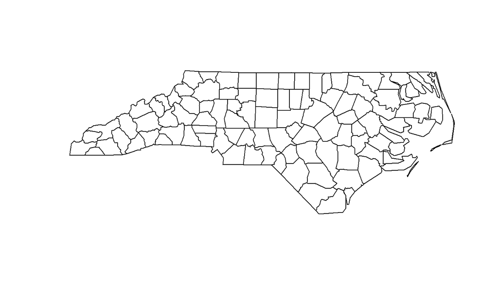

```r
st_geometry(nc) %>% plot
```

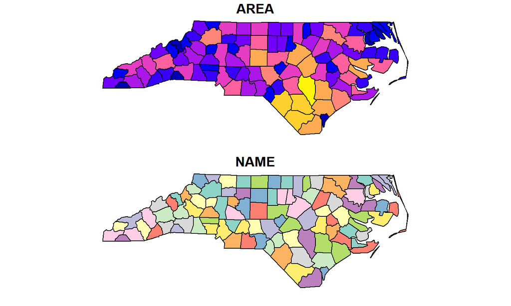

```r
# Default methods for objects
plot(nc)
```

```r
filter(nc, AREA > 0.2)
## Simple feature collection with 11 features and 2 fields
## geometry type:  MULTIPOLYGON
## dimension:      XY
## bbox:           xmin: -80.06441 ymin: 33.88199 xmax: -76.49254 ymax: 36.06665
## epsg (SRID):    4267
## proj4string:    +proj=longlat +datum=NAD27 +no_defs
## # A tibble: 11 x 3
##     AREA NAME                                                      geometry
##  * <dbl> <chr>                                           <MULTIPOLYGON [°]>
##  1 0.219 Wake     (((-78.92107 35.57886, -78.99881 35.60132, -78.93889 35.~
##  2 0.201 Randolph (((-79.76499 35.50594, -80.06441 35.5057, -80.0426 35.91~
##  3 0.207 Johnston (((-78.53874 35.31512, -78.53947 35.33646, -78.60082 35.~
##  4 0.203 Beaufort (((-77.10377 35.55019, -77.11939 35.5855, -77.14835 35.5~
##  5 0.241 Sampson  (((-78.11377 34.72099, -78.11374 34.69918, -78.15676 34.~
##  6 0.204 Duplin   (((-77.68983 34.7202, -77.92667 34.71101, -77.93931 34.7~
##  7 0.24  Robeson  (((-78.86451 34.4772, -78.91947 34.45364, -78.95074 34.4~
##  8 0.225 Bladen   (((-78.2615 34.39479, -78.32898 34.36442, -78.43794 34.3~
##  9 0.214 Pender   (((-78.02592 34.32877, -78.13024 34.36412, -78.15479 34.~
## 10 0.24  Columbus (((-78.65572 33.94867, -79.0745 34.30457, -79.04095 34.3~
## 11 0.212 Brunswi~ (((-78.65572 33.94867, -78.63472 33.97798, -78.63027 34.~
```